# Towards a passport pricing method to relieve controversial change in DR Congo

### **[Towards a passport pricing method to relieve controversial change in DR Congo](http://rpubs.com/jmcimula/passport)**

#### Septembre 19, 2017 DRC Passport Price

### 1. Current situation

The recent official news release of the [Ministry of Foreign Affairs (MINAFFET) of the Democratic Republic of Congo [1]](http://bit.ly/2yaaTVi) stating the renewal of the passport has caused a lot of ink to flow and sparked controversy. MINAFFET announces by October 16, 2017 semi-biometric passports will be no longer valid. Therefore, holders of this type of passport are required to renew it before the deadline, otherwise they will be banned from both entry and exit clearance into the Congolese territory. For those living abroad, once they land at a port of entry in DR Congo, their passport will be seized forever. Afterwards, they will only keep a copy of the passport for taking the procedure of the new passport. However, newspapers, leaders of the opposition, members of parliament [2] and Congolese people do not agree with this stringent requirement to switch from semi-biometric to biometric passport. Even some members of the party of power do not digest this decision and suggest the withdrawal of this measure on behalf of the democracy [3], since it is not fair at all.

### 2. Social Media Impact: Feedback analysis

Let’s analyze [Sonia Rolley’s](https://twitter.com/soniarolley) tweet on this matter.

> [#RDC](https://twitter.com/hashtag/RDC?src=hash) [#Passeport](https://twitter.com/hashtag/Passeport?src=hash): délivrés en 2015, annulés en 2017... après la grogne sur les réseaux sociaux, le gouvernement s'explique [pic.twitter.com/U1UlzxvSKv](https://t.co/U1UlzxvSKv)

> — Sonia Rolley (@soniarolley) [September 17, 2017](https://twitter.com/soniarolley/status/909215108659924992)

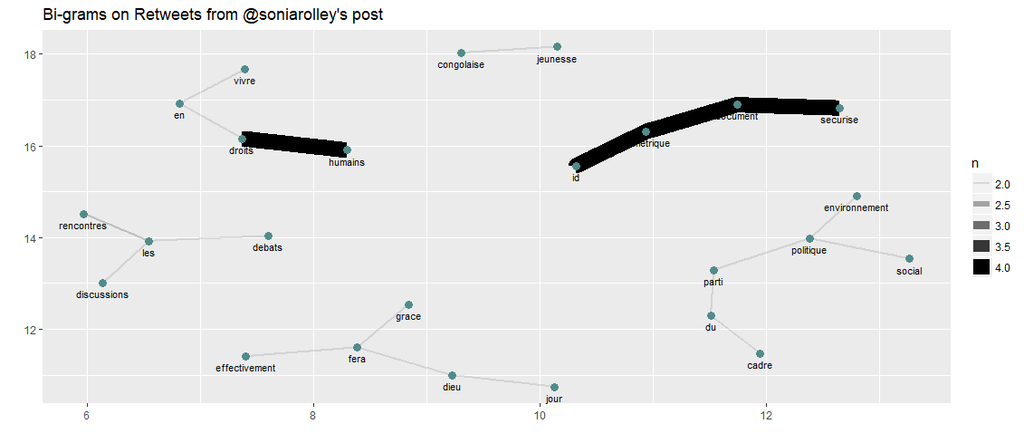

The result set from the top bigrams looks both funny and sad at the same time,it really reflects how Congolese act : **Dieu fera grace**.

### 3. Formula

To cope with this situation, knowing that money would be the main issue for majority of people, that’s why, I propose a formula to relieve tension.

Let be $Price_t$ a compelling variable (or fitting price) that motivates people to consider this change, so

$$\mathbf{Price_t} = Price\left[\
1 - \frac{1}{val}(Exp_d - Sysdate)
\right] - Gov_G (1)$$
where,

- $Price_t$: Estimation of the price to pay
- $Price$: Price fixed by MINAFFET
- $val$: Passport validity (5 years -> `5 * 365 days = 1825 days`). $val= 1825$, i.e $\frac{Price}{val}$ represents the money that costs a passport validity per day.
- $Exp_d$: Expiration date of the passport
- $Sysdate$: Today’s date (or current date)
- $Gov_G$: Government grant. This grant could be only provided to people having a valid passport, and zero dollar (`0$`) for those requesting a passport for first time.

For example, if the passport of Mr. `Masina Kimwenza` has been issued on `July 5, 2014`i.e. the expiration date will intervene on `July 4, 2019`. Suppose that MINAFFET fixes the price at `199$` and the government grants `30%` of this amount. And today’s date is `September 19, 2017`.

$$\mathbf{Price_t} = 199\left[\
1 - \frac{1}{1825}(2019/07/04 - 2017/09/19)
\right] - 199*0.3$$

$$\mathbf{Price_t} = 68.0962$$

Hence, Mr. `Masina Kimwenza` will pay `68.0962$` instead of `199$`, given that his passport still has a 653-day validity. As matter of fact, I am very confident that this formula will seamlessly solve up this issue and people won’t get frustrated.

### 4. Conclusion

In the light of the above, I would like to suggest the application of this formula for soothing the populace tension and make it easier lives of Congolese who are facing many social issues. In fact, it’s because of security reasons this sudden update must happen; we do not deny it. It’s beneficial for us to stay safe with recommendable documents and to be covered of the drawbacks to not holding a biometric passport. Then, at least, the government should consider either the remaining validity of each passport until the end of its lifecycle or grant a given percentage (between 30 and 35) on the fixed price of the passport while the renewal. Even so, the Congolese passport is damn expensive at the point many workers in Congo cannot afford it with a monthly salary. From two decades ago, this price is exponentially skyrocketing, however, my formula does not encourage the surge in prices, but it attempts to find solution to this controversy and to broker a ceasefire.

### 5. Reference

1. [1] MINAFFET (September 15, 2017), Communiqué officiel No130/0001/2017, Link (my dropbox account): http://bit.ly/2yaaTVi
2. [2] Mediacongo (September 18, 2017), Invalidation du passeport semi-biométrique : le député Alonga promet de saisir la justice: http://bit.ly/2yoALOj
3. [3] Mediacongo (September 18, 2017), Yves Kisombe : " Le retrait du passeport semi-biométrique viole le droit démocratique du peuple congolais“: http://bit.ly/2w5Uq3P

##### Related Posts

###### June 16, 2017

###### **Analyzing the Behavior of a WhatsApp Group**

[comments powered by Disqus](http://disqus.com/)